# Assignment 5

Laura Fusi

2023-03-24

```r
suppressPackageStartupMessages({
  library(AnnotationHub)
  library(ensembldb)
  library(GenomicRanges)
  library(epiwraps)
  library(rtracklayer)
  library(ggplot2)
})
ah <- AnnotationHub()
```

```
## snapshotDate(): 2022-10-31
```

# Using the peaks you downloaded last week, identify bivalent domains (H3K27me3 + H3K4me3) in mouse embryonic stem cells (mESC)

There I downloaded and imported the same data as last week:

```r
# Download and import
dir.create("mESC")
download.file("https://www.encodeproject.org/files/ENCFF247GVM/@@download/ENCFF247GVM.bed.gz", dest="mESC/H3K4me3.bed.gz")
H3K4me3_peaks <- rtracklayer::import("mESC/H3K4me3.bed.gz", format="narrowPeak")
download.file("https://www.encodeproject.org/files/ENCFF008XKX/@@download/ENCFF008XKX.bed.gz", dest="mESC/H3K27me3.bed.gz")
H3K27me3_peaks <- rtracklayer::import("mESC/H3K27me3.bed.gz", format="narrowPeak")
```

There I plotted these marks to see how often they are present together:

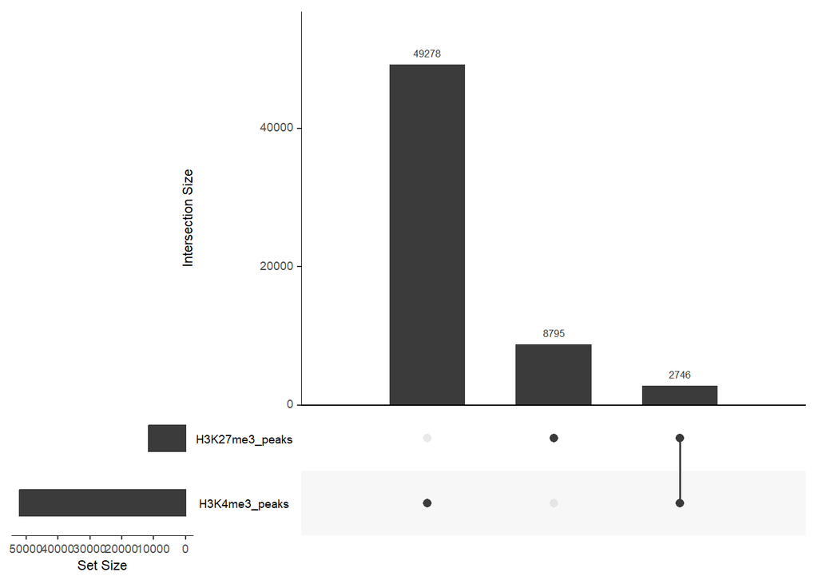

```r
px <- c()
px$H3K4me3_peaks <- H3K4me3_peaks
px$H3K27me3_peaks <- H3K27me3_peaks
regionUpset(px)
```

There I created a subset containing all H3K4me3 peak regions that overlap with H3K27me3 peak regions:

```r
p <- overlapsAny(H3K4me3_peaks, H3K27me3_peaks)
subset <- H3K4me3_peaks[p[TRUE]]
subset
```

```
## GRanges object with 3219 ranges and 6 metadata columns:
##          seqnames              ranges strand |        name     score
##             <Rle>           <IRanges>  <Rle> | <character> <numeric>
##      [1]    chr10 103027946-103028834      * |  Peak_23452        88
##      [2]    chr10   10557574-10558275      * |   Peak_8134       347
##      [3]    chr10 107271523-107272943      * |  Peak_20198       119
##      [4]    chr10 110455143-110455843      * |  Peak_17609       153
##      [5]    chr10 111010890-111011348      * |  Peak_33245        42
##      ...      ...                 ...    ... .         ...       ...
##   [3215]     chrX   93288695-93289423      * |  Peak_38814        31
##   [3216]     chrX   93298999-93299534      * |  Peak_35832        36
##   [3217]     chrX   94234909-94235926      * |  Peak_15668       185
##   [3218]     chrX   99216536-99216846      * |  Peak_35595        36
##   [3219]     chrX   99821367-99821966      * |  Peak_25491        74
##          signalValue    pValue    qValue      peak
##            <numeric> <numeric> <numeric> <integer>
##      [1]    11.13573   41.6954   39.2384       503
##      [2]    26.40615  171.9882  168.6594       557
##      [3]     9.74797   57.1880   54.6209       463
##      [4]    11.52869   74.4171   71.7384       438
##      [5]     8.75254   18.3780   16.1310       188
##      ...         ...       ...       ...       ...
##   [3215]     5.29077   12.6201   10.4467       371
##   [3216]     7.56097   15.2574   13.0477       218
##   [3217]    21.69724   90.6395   87.8586       180
##   [3218]     6.61347   15.4524   13.2398       191
##   [3219]    13.12184   34.5218   32.1202       332
##   -------
##   seqinfo: 27 sequences from an unspecified genome; no seqlengths
```

# Question: what happens to those regions upon differentiation?

## Choose a differentiated cell type (e.g. hepatocytes, neural progenitor, or smooth muscle cells)

I chose the myoblasts.

## Download the H3K27me3 and H3K4me3 peaks from this cell type

There I downloaded and imported the myoblast peak regions of the marks H3K4me3 and H3K27me3:

```r
dir.create("myo")
download.file("https://www.encodeproject.org/files/ENCFF360QRN/@@download/ENCFF360QRN.bed.gz", dest="myo/H3K4me3_myo.bed.gz")
H3K4me3_myo_peaks <- rtracklayer::import("myo/H3K4me3_myo.bed.gz", format="narrowPeak")
download.file("https://www.encodeproject.org/files/ENCFF071FEL/@@download/ENCFF071FEL.bed.gz", dest="myo/H3K27me3_myo.bed.gz")
H3K27me3_myo_peaks <- rtracklayer::import("myo/H3K27me3_myo.bed.gz", format="narrowPeak")
```

## How many of the mESC bivalent domains are, in this differentiated cell type, overlapping either mark or their combination?

There I imported the peak files for myoblasts in a unique variable and I gave them meaningful names:

```r
peakfiles_myo <- list.files("myo", full.names   = TRUE)
names(peakfiles_myo) <- peakfiles_myo
names(peakfiles_myo) <- gsub("\\.bed.gz","",basename(peakfiles_myo))
peaks_myo <- lapply(peakfiles_myo, FUN= rtracklayer::import, format="narrowPeak")
```

```r
pm <- overlapsAny(H3K4me3_myo_peaks, H3K27me3_myo_peaks)
subsetm <- H3K4me3_myo_peaks[p[TRUE]]
subsetm
```

```
## GRanges object with 4399 ranges and 6 metadata columns:
##          seqnames              ranges strand |        name     score
##             <Rle>           <IRanges>  <Rle> | <character> <numeric>
##      [1]    chr10 100495852-100495921      * |  Peak_43299        24
##      [2]    chr10 101212690-101212773      * |  Peak_43309        24
##      [3]    chr10 101911196-101911265      * |  Peak_43318        24
##      [4]    chr10 103253359-103253428      * | Peak_113978        13
##      [5]    chr10 104063029-104063099      * |  Peak_25185        35
##      ...      ...                 ...    ... .         ...       ...
##   [4395]     chrX   94121185-94123052      * |   Peak_8293       240
##   [4396]     chrX   97785331-97785487      * |  Peak_88871        24
##   [4397]     chrX   99367875-99367992      * | Peak_110284        20
##   [4398]     chrX   99456316-99456385      * |  Peak_88893        24
##   [4399]     chrX   99469799-99469952      * |  Peak_88894        24
##          signalValue    pValue    qValue      peak
##            <numeric> <numeric> <numeric> <integer>
##      [1]     3.10672   3.64489   1.31033        34
##      [2]     3.10672   3.64489   1.31033        20
##      [3]     3.10672   3.64489   1.31033        30
##      [4]     2.33004   2.49507   0.32064         3
##      [5]     3.88341   4.88947   2.47804        41
##      ...         ...       ...       ...       ...
##   [4395]    14.75694  27.48871  24.21629      1078
##   [4396]     3.10672   3.64489   1.31033        18
##   [4397]     3.00224   3.20254   0.99505        63
##   [4398]     3.10672   3.64489   1.31033        53
##   [4399]     3.10672   3.64489   1.31033        92
##   -------
##   seqinfo: 24 sequences from an unspecified genome; no seqlengths
```

There I created a variable including the subset that I created in the first part and the myoblast peaks for the regions needed, so that I could use it for the plots.

```r
peaksforplot <- peaks_myo
peaksforplot$subset <- subset
```

```r
lapply(peaks_myo, FUN=function(x) sum(overlapsAny(subset,x)))
```

```
## $H3K27me3_myo
## [1] 1593
##
## $H3K4me3_myo
## [1] 1198
```

```r
sum(overlapsAny(subset, subsetm))
```

```
## [1] 94
```

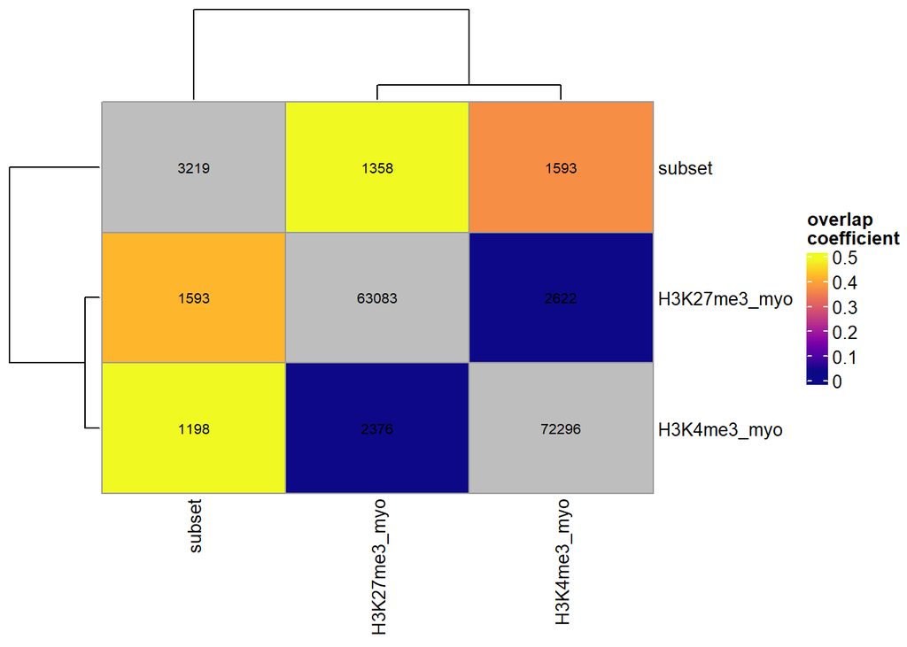

```r
regionOverlaps(peaksforplot)
```

There I created a plot showing the size of the intersection of different regions:

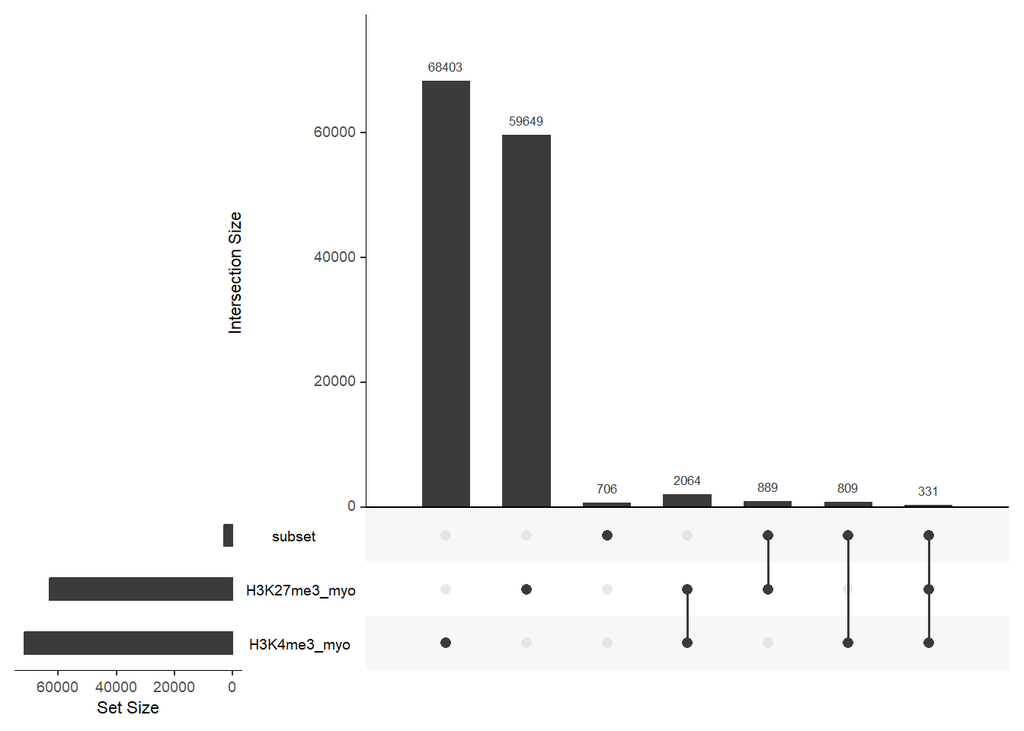

```r
regionUpset(peaksforplot)
```

This last plot, as well as the numbers above, show that differentiated cells have mostly either one mark or the other one in a certain region, while only a few regions still have both marks. Many of these regions do not correspond to those in the mESC subset.